# Multivariate and Spatiotemporal Visualization

## Method: Content analysis of paleoecological visualizations

### Method justification.

Visual content analysis describes the systematic interpretation of a coherent corpus of artifacts by their constituent visual elements (Rose 2012). Content analysis is a common social science method for rigorous identification of themes, trends, and outliers in secondary sources such as text documents and transcripts (Suchan & Brewer 2000), and visual approaches have been modified for ‘design analysis’ in cartography and related fields to expose the designer’s intentions and authorship of the visualization (e.g., Kent & Vujakovic 2009, Slocum et al. 2011, Muehlenhaus 2012, Kelly 2015, White et al. 2017, Roth et al. under review). Increasingly, visual content analysis examines the graphic representation, the data underlying the representation, and visual interfaces for manipulating the data through the representation (e.g., Roth et al. 2015, Fish & Calvert 2016, Degbelo & Kauppinen 2018). Visual content analysis provides a benchmark for contemporary design practices and, when compared to empirically-derived best practices for visualization design, reveals domain-specific gaps and opportunities for future visualization research and practice (Muehlenhaus 2011).

### Case study.

We collected our sample of paleoecological charts, maps, and other visualizations from publications describing projects using the Neotoma database. We focused on Neotoma for several reasons (see Williams et al. 2018 for a review). First, Neotoma is a community-curated data resource that organizes a range of valuable constituent databases in paleoecology, such as the African, Chinese, Europe, Japanese, Latin American, North American, and Siberian and Russian Far East Pollen Databases, centralized efforts such as FAUNMAP and NANODe, university repositories such as the Academy of Natural Sciences of Drexel University and the North Dakota State University NANODe, and Neotoma-specific collections such as the Neotoma Midden Database and the Neotoma Testate Amoebae Database. Second, Neotoma has a flexible data model specification that permits spatiotemporal and multivariate dimensions, key visualization considerations for paleoecoinformatics. Third, Neotoma has robust governance and validation processes, drawing out and documenting sources of uncertainty while overall improving the quality of its contents. Finally, Neotoma has an open API that enables third party visualization on the web and mobile devices, such as our own Flyover Country mobile application (Loeffler et al. submitted). Thus, design analysis of existing uses of the Neotoma API directly informed development of Flyover Country.

### Sample

```r
paper_count <- model_out[[1]] %>%
  distinct(Article) %>%
  nrow()

figure_count <- model_out[[1]] %>%
  filter(!Figure == "") %>%
  nrow()

chart_count <- sum(model_out[[1]]$Num_Visuals, na.rm = TRUE)

final_count <- 1

fig_per_paper <- rep(1, paper_count)

assertthat::assert_that(chart_count >= figure_count, msg = "Analysis is reporting more figures than (sub)charts.")
assertthat::assert_that(figure_count >= paper_count, msg = "Analysis is reporting more papers than figures.")
assertthat::assert_that(all(fig_per_paper > 0), msg = "Some papers report 0 figures.")
assertthat::assert_that(final_count <= figure_count, msg = "Figure filtering resulted in more figures than otherwise.")
```

### Procedure.

**Table 1**. Interactive visualizations considered in the visual content analysis. Bold indicates resources that use the Neotoma API.

| Interactive Visualization | Platform | Coordinating Team | Hyperlink |
| --- | --- | --- | --- |
| **Neotoma Explorer** | Open Web | University of Wisconsin / Penn State | https://apps.neotomadb.org/explorer/ |
| Macrostrat Map | Open Web | University of Wisconsin | https://macrostrat.org/map/ |
| PBDB Navigator | Open Web | University of Wisconsin | https://paleobiodb.org/navigator/ |
| **Flyover Country** | Mobile App | University of Minnesota | https://flyovercountry.io/ |
| Rock’d | Mobile App | University of Wisconsin | https://rockd.org/ |

## Results: Current practices in paleoecoinformatics visualization

### Data Types

```r
data_types <- c('2_Dimensional',
                '3_Dimensional',
                'N_Dimensional',
                'Temporal',
                'Tree',
                'Network')

dt_plots <- model_out[[1]] %>%
  select(data_types) %>%
  tidyr::gather() %>%
  na.omit
```

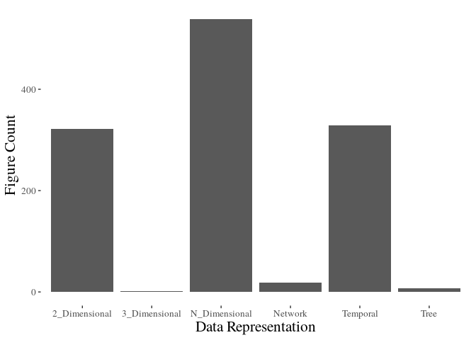

```r
ggplot(dt_plots) +
  geom_histogram(aes(x = key), stat = 'count') +
  xlab("Data Representation") +
  ylab("Figure Count") +
  theme_tufte() +
  theme(axis.title = element_text(size = 16),
        axis.text = element_text(size = 10))
```

### Plot Types

```r
plot_types <- c('Article',
                'Figure',
                'Visual')

plot_plots <- model_out[[1]] %>%
  select(plot_types) %>%
  na.omit

mean_fig <- mean((plot_plots %>%
  group_by(Article) %>%
  summarise(n = n()))$n)

mean_plt <- mean((plot_plots %>%
  group_by(Article) %>%
  summarise(n = length(unique(Visual))))$n)

poly_plot <- round(sum(stringr::str_detect(plot_plots$Visual, "\\/")) / nrow(plot_plots) * 100, 1)

multi_plot <- round(sum(stringr::str_detect(plot_plots$Visual, "multi")) / nrow(plot_plots) * 100, 1)
```

This analysis provides us with 107 distinct visual representation (plot) types in the literature. The average paper in the sample contains 7.02 unique figures, with 4.91 unique plot types.

The most common plot types in the dataset are small multiple line graphs, line graph, small multiple scatter plots. This represents the emphasis on standard statistical and time-series analysis (likely).

Of the plot types, only 6.3% of figures combine plot types, representing multiple forms of data using multiple visual representations in a single figure (plot or sub-plot). Of all figures approximately 48% represent data using multiples of a single visual representation type. Often, these represent multiple time slices, or multiple taxa at the same time slice.

### Dataset Names (histogram)

```r
trans_table <- convert_datasets(model_out[[1]],
                                "Dataset",
                                filename = "data/output/translation_dataset.csv")
dataset_names <- model_out[[1]] %>%
  select(Dataset) %>%
  left_join(trans_table, by = c("Dataset" = "xldataset"))
```

These are very granular currently. There are 58 distinct classes in the grouped list.

[figure not shown]

```r
ggplot(na.omit(dataset_names)) +
  geom_histogram(aes(x = broader), stat = 'count') +
  xlab("Dataset Type") +
  ylab("Figure Count") +
  theme_tufte() +
  theme(axis.title = element_text(size = 16),
        axis.text = element_text(size = 10))
```

### Tag cloud or text visualization: actual dataset names

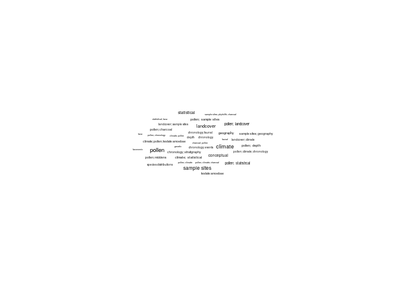

```r
dataset_sum <- dataset_names %>%
  group_by(broader)  %>%
  summarise(n = n()) %>%
  filter(n > 1)

ggplot(dataset_sum, aes(label = broader, size = n)) +
  geom_text_wordcloud() +
  theme_tufte()
```

### Representation

Variable representation is encoded in the images, as part of the presence or absence of a field.

| Enoding | Meaning |
| --- | --- |
| + | Representation of separate categories rather than numerical data |
| * | Analyses done using different sources of paleoecological data (eg. Pollen; midden; macrofossils) |
| ** | Multi hue color scheme that uses both color hue and value |
| ~ | Implied elevation data for basemap. Uses color value with dark areas as high elevation and light areas as low elevation |
| ` | Implicit coding but never explicitly stated. (eg land vs water represented by hue) |

```r
repr_types <- c('Article',
                'Figure',
                'Location',
                'Size',
                'Shape',
                'Orientation',
                'Texture',
                'Color_Hue',
                'Color_Value',
                'Color_Saturation',
                'Arrangement',
                'Crispness',
                'Transparency')

rep_plots <- model_out[[1]] %>%
  select(repr_types) %>%
  tidyr::gather("element", "representation", -Article, -Figure) %>%
  na.omit
```

#### Static information representation encodings

This is by figure, not normalized by paper. This may be biased by papers with a large number of figures.

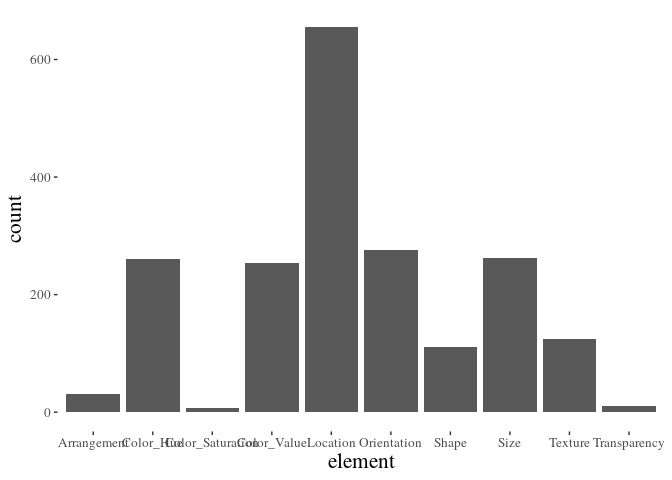

```r
ggplot(rep_plots, aes(x = element)) +
  geom_histogram(stat = 'count') +
  theme_tufte() +
  theme(axis.title = element_text(size = 16),
        axis.text = element_text(size = 10))
```

#### Static Information Venn Diagram

```r
elem_list <- unique(rep_plots$element) %>%
  map(function(x) {
      rep_plots %>%
        group_by(Article, Figure) %>%
        summarise(ppr = x %in% element)
  }) %>%
  map(function(x) which(x$ppr))

names(elem_list) <- unique(rep_plots$element)

venn.plot <- venn.diagram(
    x = elem_list[c("Orientation",
                  "Size",
                  "Color_Value",
                  "Color_Hue")],
    euler.d = TRUE,
  scaled= TRUE,
    filename = "Euler_3set_scaled.tiff",
    cex = 2.5,
    cat.cex = 2.5,
    cat.pos = 0
    )
```

[figure not shown]

### Novel Techniques

Petal plots Flag plots

## Conclusions and Future Directions

· Innovative Multivariate and Spatiotemporal Representation Techniques · Scaling Interactions to Growing Databases · Supporting Mobile · Harnessing the Potential of Big Data for Multiple Use Cases

## Acknowledgements

This research was funded by the National Science Foundation grants #1550707, and #1550855, and #1550913.